# Permutation Tests under Stratified Randomization

- Show All Code
- Hide All Code
- View Source

Applied Causal Analysis — LMU Munich

Author

Mauricio Olivares

Published

June 16, 2026

## 1 Overview

This document extends the permutation-testing framework to **stratified randomized experiments**, in which treatment is assigned independently across pre-specified strata (e.g., classrooms, blocks, matched pairs). We work with the empirical application built into the `sreg` package, based on Chong et al. (2016), who study the effect of an iron-supplementation program on school-age children in Peru. The intervention assigned children to one of two dosage arms or to control, stratified by classroom.

Two ingredients combine here:

1. The **saturated, strata-adjusted estimator** of Bugni et al. (2018), with an HC1 studentized test statistic, as implemented in `sreg::sreg()`.
2. A **permutation test that respects the stratification**, recomputing the test statistic after permuting outcomes *within* each stratum rather than across the whole sample.

The goal is to test whether assignment to the low-dose arm affected the number of iron pills children actually took, relative to control — a compliance outcome, not the final health/cognitive outcome of the trial.

## 2 Setup

We load the required packages and the course function library, and fix the random seed using the parallel-safe `L'Ecuyer-CMRG` generator.

**Load libraries and function library**

```r
rm(list = ls())

library(tidyverse)
library(sreg)
library(knitr)

# Source the course function library (same directory as this file)
source("ACA_Function_Library.r")

set.seed(42, kind = "L'Ecuyer-CMRG")
```

**Note**

The `L'Ecuyer-CMRG` generator is safe for parallel execution and is used throughout the course so that simulation results are reproducible across machines and sessions.

## 3 The Data

The `AEJapp` data ships with the `sreg` package. We work with three outcomes — `pills_taken`, `gradesq34` (average grade across the third and fourth quarters), and `wii_total` (a Wii-based cognitive game score) — together with `treatment` (1 = low dose, 2 = high dose, 3 = control) and `class_level`, the classroom stratum.

**Load and recode the AEJapp data**

```r
data("AEJapp")

data <- AEJapp %>%
  select(gradesq34, pills_taken, wii_total, treatment, class_level) %>%
  haven::zap_labels() %>%
  mutate(
    treatment = ifelse(treatment == 3, 0, treatment),
    S = class_level
  )
```

Recoding `treatment == 3` to `0` puts control at the reference level. We then split the sample into two two-arm sub-experiments: **low dose vs. control** and **high dose vs. control**.

**Construct the low-dose and high-dose sub-experiments**

```r
data_low  <- data %>% filter(treatment != 2)
data_high <- data %>% filter(treatment != 1)
```

```r
data_low %>%
  group_by(treatment, S) %>%
  summarize(n = n(), .groups = "drop") %>%
  kable()
```

Table 1: Stratum sizes by arm, low-dose sub-experiment.

| treatment | S | n |
| --- | --- | --- |
| 0 | 1 | 15 |
| 0 | 2 | 19 |
| 0 | 3 | 16 |
| 0 | 4 | 12 |
| 0 | 5 | 10 |
| 1 | 1 | 16 |
| 1 | 2 | 19 |
| 1 | 3 | 15 |
| 1 | 4 | 10 |
| 1 | 5 | 10 |

```r
data_high %>%
  group_by(treatment, S) %>%
  summarize(n = n(), .groups = "drop") %>%
  kable()
```

Table 2: Stratum sizes by arm, high-dose sub-experiment.

| treatment | S | n |
| --- | --- | --- |
| 0 | 1 | 15 |
| 0 | 2 | 19 |
| 0 | 3 | 16 |
| 0 | 4 | 12 |
| 0 | 5 | 10 |
| 2 | 1 | 17 |
| 2 | 2 | 20 |
| 2 | 3 | 15 |
| 2 | 4 | 11 |
| 2 | 5 | 10 |

Strata vary in size across classrooms, which is exactly the setting the saturated estimator of Bugni et al. (2018) is designed for: it does not require strata to be of equal size, nor balanced treatment shares within each stratum.

## 4 The Stratified Test Statistic

For the low-dose sub-experiment, we estimate the average treatment effect of low-dose iron supplementation on `pills_taken` using `sreg::sreg()`, which returns a strata-weighted difference-in-means estimator $\hat\tau$ together with an HC1-adjusted robust standard error $\widehat{\mathrm{se}}(\hat\tau)$.

**Fit the stratified estimator on the low-dose sub-experiment**

```r
result <- sreg::sreg(Y = data_low$pills_taken, S = data_low$S, D = data_low$treatment)
print(result)
```

```
Saturated Model Estimation Results under CAR
Observations: 142
Number of treatments: 1
Number of strata: 5
Setup: big strata
Standard errors: adjusted (HC1)
Treatment assignment: individual level
Covariates used in linear adjustments:
---
Coefficients:
      Tau   As.se  T-stat P-value CI.left(95%) CI.right(95%) Significance
1 3.95464 1.65947 2.38307 0.01717      0.70213       7.20714            *
---
Signif. codes:  0 `***` 0.001 `**` 0.01 `*` 0.05 `.` 0.1 ` ` 1
```

The reported `t.stat` is the studentized statistic

$$T_n \;=\; \frac{\hat\tau}{\widehat{\mathrm{se}}(\hat\tau)},$$

which we can reconstruct directly from the two components:

**Verify T_n = tau_hat / se_robust**

```r
result$t.stat
```

```
[1] 2.38307
```

**Verify T_n = tau_hat / se_robust**

```r
result$tau / result$se.rob
```

```
[1] 2.38307
```

## 5 Permutation Test under Stratification

The function `permute_within_strata()` permutes $Y$ independently within each stratum, $M$ times. For each permuted outcome vector, `test_stat_strata()` recomputes the studentized statistic, holding the realized treatment and strata fixed.

**Set the number of permutations and the nominal level**

```r
M     <- 1000
alpha <- 0.025
```

**Generate within-strata permutations of the outcome**

```r
Sn <- permute_within_strata(Y = data_low$pills_taken, S = data_low$S, M)
Wn <- cbind(Sn, data_low$pills_taken)
```

The last column of `Wn` is the *unpermuted* outcome, so recomputing the statistic on that column — with the original treatment vector — reproduces the observed $T_n$ shown above. This is what lets `Tn_all` double as both the permutation distribution and the observed statistic, with no separate bookkeeping needed.

**Recompute T_n across all permuted and the original outcome vector**

```r
Tn_all <- sapply(1:ncol(Wn), function(i) {
  test_stat_strata(Y = Wn[, i], S = data_low$S, D = data_low$treatment)
})
```

The permutation critical value is the $k$-th order statistic of `Tn_all`, with $k = M - \lfloor M\alpha \rfloor$, implementing the one-sided upper-tail rejection region $\{T_n > T_n^{(k)}\}$ at nominal level $\alpha$.

**Compute the permutation critical value**

```r
k    <- M - floor(M * alpha)
Tn_k <- sort(Tn_all)[k]
Tn_k
```

```
[1] 1.78554
```

**Plot the randomization distribution against N(0,1)**

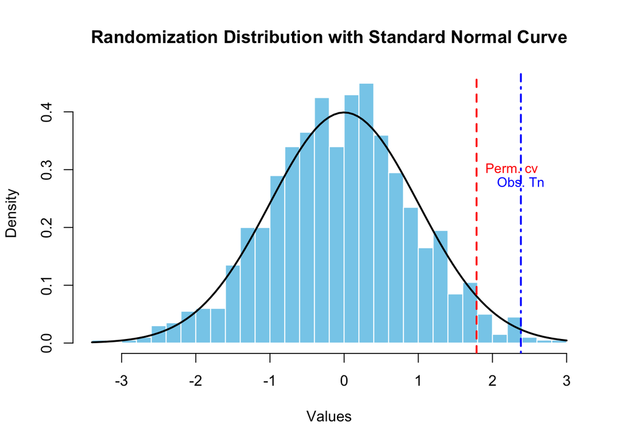

Figure 1: Randomization distribution of $T_n$ across $M = 1{,}000$ within-strata permutations, overlaid with the standard normal density. The red dashed line marks the permutation critical value $T_n^{(k)}$; the blue dotted line marks the observed statistic.

```r
plot_PermDist_stud(Tn_all, result$t.stat, Tn_k)
```

**Apply the permutation decision rule**

```r
perm_test(Tn_all, alpha)
```

```
[1] 1
```

**NoteAsymptotic Equivalence**

Because $T_n$ is studentized, $T_n \xrightarrow{d} \mathcal{N}(0,1)$ under $H_0$ as the number and size of strata grow, by the results in Bugni et al. (2018). The permutation critical value $T_n^{(k)}$ converges to the same normal quantile $z_{1-\alpha}$, so the permutation and asymptotic decision rules are asymptotically equivalent — with no loss of power — while the permutation test remains exactly valid in finite samples under the randomization hypothesis, regardless of how well the normal approximation fits.

**ImportantRandomization Hypothesis under Stratification**

Let $S_i \in \{1, \dots, K\}$ denote the stratum of unit $i$. Under the sharp null $H_0 : Y_i(1) = Y_i(0)$ for all $i$, and under covariate-adaptive randomization that assigns treatment independently across strata, the vector of realized outcomes within stratum $s$ is **exchangeable** with respect to the within-stratum treatment assignment. Equivalently, conditional on $S_i = s$, permuting the *realized outcomes* $Y_i$ among units in stratum $s$ — holding $D_i$ and $S_i$ fixed — induces the same distribution over the test statistic as permuting the *treatment labels* within stratum $s$ and holding $Y_i$ fixed.

## 6 Discussion

Compare the permutation critical value `Tn_k` to the asymptotic one-sided critical value at the same level, $z_{1-\alpha}$:

**Compare permutation and asymptotic critical values**

```r
c(permutation = Tn_k, asymptotic = qnorm(1 - alpha))
```

```
permutation  asymptotic
   1.785540    1.959964
```

## 7 Take-home Exercise

Repeat the analysis above for the **high-dose sub-experiment** (`data_high`), testing whether high-dose iron supplementation affected `pills_taken`. Then repeat it once more using `gradesq34` as the outcome in either sub-experiment. Do the permutation and asymptotic decision rules continue to agree? Does the conclusion about compliance (`pills_taken`) carry over to the downstream educational outcome (`gradesq34`)?

## 8 References

Bugni, Federico A., Ivan A. Canay, and Azeem M. Shaikh. 2018. “Inference Under Covariate-Adaptive Randomization.” *Journal of the American Statistical Association* 113 (524): 1784–96. https://doi.org/10.1080/01621459.2017.1375934.

Chong, Alberto, Isabelle Cohen, Erica Field, Eduardo Nakasone, and Maximo Torero. 2016. “Iron Deficiency and Schooling Attainment in Peru.” *American Economic Journal: Applied Economics* 8 (4): 222–55. https://doi.org/10.1257/app.20140494.